# Praktikum 1 Visualisasi Data - Paralel 2

Cindy Indriyani

28 January 2026

Proporsi Nilai Praktikum

- Kehadiran: 15%
- Keaktifan: 10%
- Tugas/Latihan: 25%
- Projek: 50%

# Software yang Digunakan

Pada praktikum ini digunakan beberapa software utama, yaitu:

## R

R merupakan bahasa pemrograman yang digunakan untuk analisis statistika, pengolahan data, dan visualisasi data.

## RStudio

RStudio adalah Integrated Development Environment (IDE) untuk R yang memudahkan pengguna dalam menulis, menjalankan, dan mengelola kode R.

## R Markdown

R Markdown digunakan untuk menggabungkan kode R, output, dan penjelasan dalam satu dokumen, sehingga memudahkan pembuatan laporan praktikum.

# Environment RStudio

RStudio terdiri dari empat panel utama:

## Source

Panel Source digunakan untuk menulis script R (`.R`) atau dokumen R Markdown (`.Rmd`).

Kode pada panel ini dapat dijalankan menggunakan shortcut:

- **Ctrl + Enter** (Windows/Linux)
- **Cmd + Enter** (Mac)

## Console

Panel Console digunakan untuk menjalankan perintah R secara langsung.

Hasil eksekusi kode dan pesan error akan muncul di panel ini.

## Environment

Panel Environment menampilkan objek yang sedang aktif di R, seperti:

- data frame
- vektor
- model statistik

## Files, Plots, Packages, dan Help

- **Files**: menampilkan file dan folder pada working directory
- **Plots**: menampilkan hasil visualisasi
- **Packages**: menampilkan package yang terpasang
- **Help**: menampilkan dokumentasi fungsi R

# Working Directory

Working directory adalah folder tempat R membaca dan menyimpan file.

Untuk mengecek working directory:

```r
getwd()
```

```
## [1] "C:/Visualisasi Data Praktikum P2"
```

# Package R

Package yang digunakan dalam praktikum ini meliputi `DataExplorer` untuk eksplorasi data otomatis, `corrplot` untuk visualisasi matriks korelasi, `tidyverse` untuk manipulasi data, `ggpubr` dan `ggplot2` untuk visualisasi data, serta package bawaan R (base) untuk fungsi visualisasi dasar.

Contoh package bawaan:

- read.csv(): Digunakan untuk membaca file data berformat CSV (Comma Separated Values) dan mengimpornya ke dalam R sebagai data frame.
- head(): Menampilkan beberapa baris teratas dari suatu objek data (default 6 baris) untuk melihat gambaran awal data.
- str(): Menampilkan struktur internal data, termasuk tipe data setiap variabel dan contoh nilainya.
- summary(): Memberikan ringkasan statistik deskriptif data, seperti minimum, maksimum, mean, median, dan kuartil.
- plot(): Fungsi dasar untuk membuat berbagai jenis grafik, seperti scatter plot, line plot, dan visualisasi sederhana lainnya.
- hist(): Digunakan untuk membuat histogram guna melihat distribusi suatu variabel numerik.
- points(): Menambahkan titik ke grafik yang sudah ada, biasanya digunakan untuk overlay atau membedakan kelompok data.
- lines(): Menambahkan garis pada grafik yang sudah ada, sering digunakan untuk menampilkan tren atau hubungan antar data.
- text(): Menambahkan teks atau label pada grafik di posisi koordinat tertentu.
- legend(): Menambahkan keterangan (legend) pada grafik untuk menjelaskan arti warna, simbol, atau garis yang digunakan.
- abline(): Menambahkan garis referensi ke dalam grafik, baik garis horizontal, vertikal, maupun garis dengan persamaan tertentu.
- density(): Menghitung estimasi fungsi kerapatan (density estimation) dari data numerik, yang sering digunakan untuk membuat kurva density.

```r
#install.packages(c(
  #"DataExplorer",
  #"corrplot",
  #"tidyverse",
  #"ggpubr",
  #"ggplot2"))
```

## Load Data

```r
bank <- read.csv("C:/Visualisasi Data Praktikum P2/bank.csv", sep=",")
bank <- as.data.frame(bank)
```

## Eksplorasi Data

```r
# Melihat data teratas
head(bank)
```

|  | age | job | marital | education | default | balance | housing | loan | contact | day | month | duration | campaign | pdays | previous | y | weight | hight |
| --- | --- | --- | --- | --- | --- | --- | --- | --- | --- | --- | --- | --- | --- | --- | --- | --- | --- | --- |
| 1 | 30 | unemployed | married | primary | no | 1787 | no | no | cellular | 19 | oct | 79 | 1 | -1 | 0 | no | 63.2 | 160.9 |
| 2 | 33 | services | married | secondary | no | 4789 | yes | yes | cellular | 11 | may | 220 | 1 | 339 | 4 | no | 68.5 | 165.3 |
| 3 | 35 | management | single | tertiary | no | 1350 | yes | no | cellular | 16 | apr | 185 | 1 | 330 | 1 | no | 78.5 | 173.5 |
| 4 | 30 | management | married | tertiary | no | 1476 | yes | yes | unknown | 3 | jun | 199 | 4 | -1 | 0 | no | 95.3 | 187.2 |
| 5 | 59 | blue-collar | married | secondary | no | 0 | yes | no | unknown | 5 | may | 226 | 1 | -1 | 0 | no | 60.1 | 158.3 |
| 6 | 35 | management | single | tertiary | no | 747 | no | no | cellular | 23 | feb | 141 | 2 | 176 | 3 | no | 94.8 | 186.8 |

```r
head(bank, 10) #10 data teratas
```

|  | age | job | marital | education | default | balance | housing | loan | contact | day | month | duration | campaign | pdays | previous | y | weight | hight |
| --- | --- | --- | --- | --- | --- | --- | --- | --- | --- | --- | --- | --- | --- | --- | --- | --- | --- | --- |
| 1 | 30 | unemployed | married | primary | no | 1787 | no | no | cellular | 19 | oct | 79 | 1 | -1 | 0 | no | 63.2 | 160.9 |
| 2 | 33 | services | married | secondary | no | 4789 | yes | yes | cellular | 11 | may | 220 | 1 | 339 | 4 | no | 68.5 | 165.3 |
| 3 | 35 | management | single | tertiary | no | 1350 | yes | no | cellular | 16 | apr | 185 | 1 | 330 | 1 | no | 78.5 | 173.5 |
| 4 | 30 | management | married | tertiary | no | 1476 | yes | yes | unknown | 3 | jun | 199 | 4 | -1 | 0 | no | 95.3 | 187.2 |
| 5 | 59 | blue-collar | married | secondary | no | 0 | yes | no | unknown | 5 | may | 226 | 1 | -1 | 0 | no | 60.1 | 158.3 |
| 6 | 35 | management | single | tertiary | no | 747 | no | no | cellular | 23 | feb | 141 | 2 | 176 | 3 | no | 94.8 | 186.8 |
| 7 | 36 | self-employed | married | tertiary | no | 307 | yes | no | cellular | 14 | may | 341 | 1 | 330 | 2 | no | 97.2 | 188.7 |
| 8 | 39 | technician | married | secondary | no | 147 | yes | no | cellular | 6 | may | 151 | 2 | -1 | 0 | no | 82.8 | 177.1 |
| 9 | 41 | entrepreneur | married | tertiary | no | 221 | yes | no | unknown | 14 | may | 57 | 2 | -1 | 0 | no | 81.2 | 175.8 |
| 10 | 43 | services | married | primary | no | -88 | yes | yes | cellular | 17 | apr | 313 | 1 | 147 | 2 | no | 53.1 | 152.5 |

```r
bank[1:10,]
```

|  | age | job | marital | education | default | balance | housing | loan | contact | day | month | duration | campaign | pdays | previous | y | weight | hight |
| --- | --- | --- | --- | --- | --- | --- | --- | --- | --- | --- | --- | --- | --- | --- | --- | --- | --- | --- |
| 1 | 30 | unemployed | married | primary | no | 1787 | no | no | cellular | 19 | oct | 79 | 1 | -1 | 0 | no | 63.2 | 160.9 |
| 2 | 33 | services | married | secondary | no | 4789 | yes | yes | cellular | 11 | may | 220 | 1 | 339 | 4 | no | 68.5 | 165.3 |
| 3 | 35 | management | single | tertiary | no | 1350 | yes | no | cellular | 16 | apr | 185 | 1 | 330 | 1 | no | 78.5 | 173.5 |
| 4 | 30 | management | married | tertiary | no | 1476 | yes | yes | unknown | 3 | jun | 199 | 4 | -1 | 0 | no | 95.3 | 187.2 |
| 5 | 59 | blue-collar | married | secondary | no | 0 | yes | no | unknown | 5 | may | 226 | 1 | -1 | 0 | no | 60.1 | 158.3 |
| 6 | 35 | management | single | tertiary | no | 747 | no | no | cellular | 23 | feb | 141 | 2 | 176 | 3 | no | 94.8 | 186.8 |
| 7 | 36 | self-employed | married | tertiary | no | 307 | yes | no | cellular | 14 | may | 341 | 1 | 330 | 2 | no | 97.2 | 188.7 |
| 8 | 39 | technician | married | secondary | no | 147 | yes | no | cellular | 6 | may | 151 | 2 | -1 | 0 | no | 82.8 | 177.1 |
| 9 | 41 | entrepreneur | married | tertiary | no | 221 | yes | no | unknown | 14 | may | 57 | 2 | -1 | 0 | no | 81.2 | 175.8 |
| 10 | 43 | services | married | primary | no | -88 | yes | yes | cellular | 17 | apr | 313 | 1 | 147 | 2 | no | 53.1 | 152.5 |

```r
# Struktur kolom
str(bank)
```

```
## 'data.frame':    4521 obs. of  18 variables:
##  $ age      : int  30 33 35 30 59 35 36 39 41 43 ...
##  $ job      : chr  "unemployed" "services" "management" "management" ...
##  $ marital  : chr  "married" "married" "single" "married" ...
##  $ education: chr  "primary" "secondary" "tertiary" "tertiary" ...
##  $ default  : chr  "no" "no" "no" "no" ...
##  $ balance  : int  1787 4789 1350 1476 0 747 307 147 221 -88 ...
##  $ housing  : chr  "no" "yes" "yes" "yes" ...
##  $ loan     : chr  "no" "yes" "no" "yes" ...
##  $ contact  : chr  "cellular" "cellular" "cellular" "unknown" ...
##  $ day      : int  19 11 16 3 5 23 14 6 14 17 ...
##  $ month    : chr  "oct" "may" "apr" "jun" ...
##  $ duration : int  79 220 185 199 226 141 341 151 57 313 ...
##  $ campaign : int  1 1 1 4 1 2 1 2 2 1 ...
##  $ pdays    : int  -1 339 330 -1 -1 176 330 -1 -1 147 ...
##  $ previous : int  0 4 1 0 0 3 2 0 0 2 ...
##  $ y        : chr  "no" "no" "no" "no" ...
##  $ weight   : num  63.2 68.5 78.5 95.3 60.1 94.8 97.2 82.8 81.2 53.1 ...
##  $ hight    : num  161 165 174 187 158 ...
```

```r
# Ringkasan Data
summary(bank)
```

```
##       age            job              marital           education
##  Min.   :19.00   Length:4521        Length:4521        Length:4521
##  1st Qu.:33.00   Class :character   Class :character   Class :character
##  Median :39.00   Mode  :character   Mode  :character   Mode  :character
##  Mean   :41.17
##  3rd Qu.:49.00
##  Max.   :87.00
##    default             balance        housing              loan
##  Length:4521        Min.   :-3313   Length:4521        Length:4521
##  Class :character   1st Qu.:   69   Class :character   Class :character
##  Mode  :character   Median :  444   Mode  :character   Mode  :character
##                     Mean   : 1423
##                     3rd Qu.: 1480
##                     Max.   :71188
##    contact               day           month              duration
##  Length:4521        Min.   : 1.00   Length:4521        Min.   :   4
##  Class :character   1st Qu.: 9.00   Class :character   1st Qu.: 104
##  Mode  :character   Median :16.00   Mode  :character   Median : 185
##                     Mean   :15.92                      Mean   : 264
##                     3rd Qu.:21.00                      3rd Qu.: 329
##                     Max.   :31.00                      Max.   :3025
##     campaign          pdays           previous            y
##  Min.   : 1.000   Min.   : -1.00   Min.   : 0.0000   Length:4521
##  1st Qu.: 1.000   1st Qu.: -1.00   1st Qu.: 0.0000   Class :character
##  Median : 2.000   Median : -1.00   Median : 0.0000   Mode  :character
##  Mean   : 2.794   Mean   : 39.77   Mean   : 0.5426
##  3rd Qu.: 3.000   3rd Qu.: -1.00   3rd Qu.: 0.0000
##  Max.   :50.000   Max.   :871.00   Max.   :25.0000
##      weight          hight
##  Min.   : 50.0   Min.   :150.0
##  1st Qu.: 62.0   1st Qu.:159.9
##  Median : 74.0   Median :169.8
##  Mean   : 74.6   Mean   :170.3
##  3rd Qu.: 87.7   3rd Qu.:181.1
##  Max.   :100.0   Max.   :191.0
```

```r
# Missing value check
sum(is.na(bank))
```

```
## [1] 0
```

## 1.Data Explorer

Proses eksplorasi data otomatis untuk kebutuhan analisis dan pemodelan prediktif, agar tidak perlu EDA manual satu persatu.

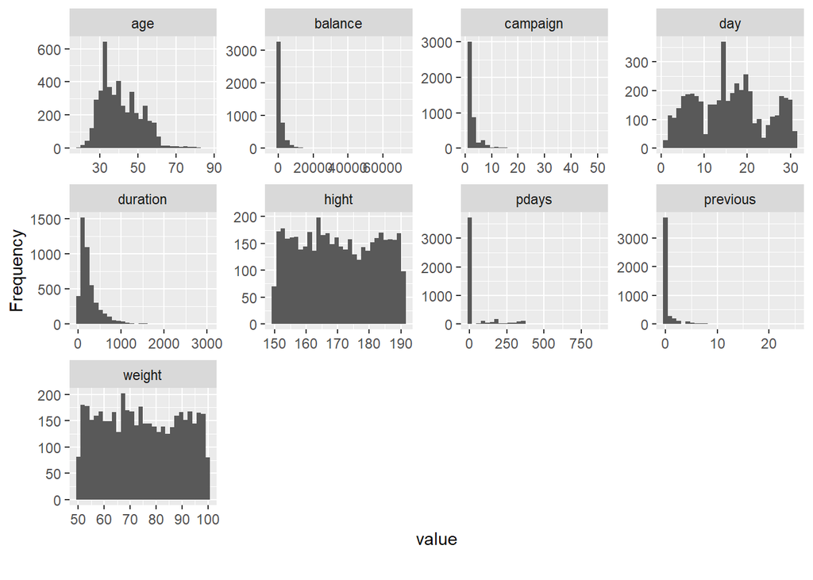

```r
library(DataExplorer)
plot_histogram(bank)
```

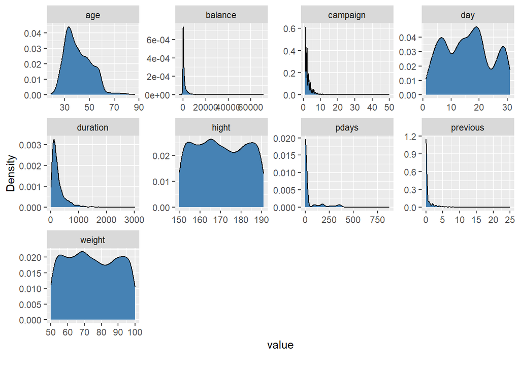

```r
plot_density(bank,geom_density_args = list(fill="steelblue"))
```

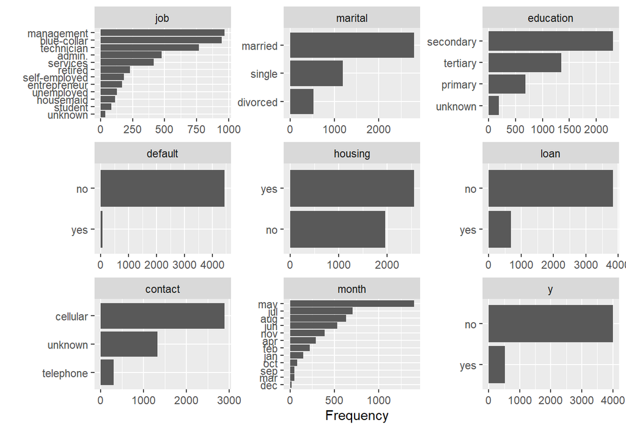

```r
plot_bar(bank)
```

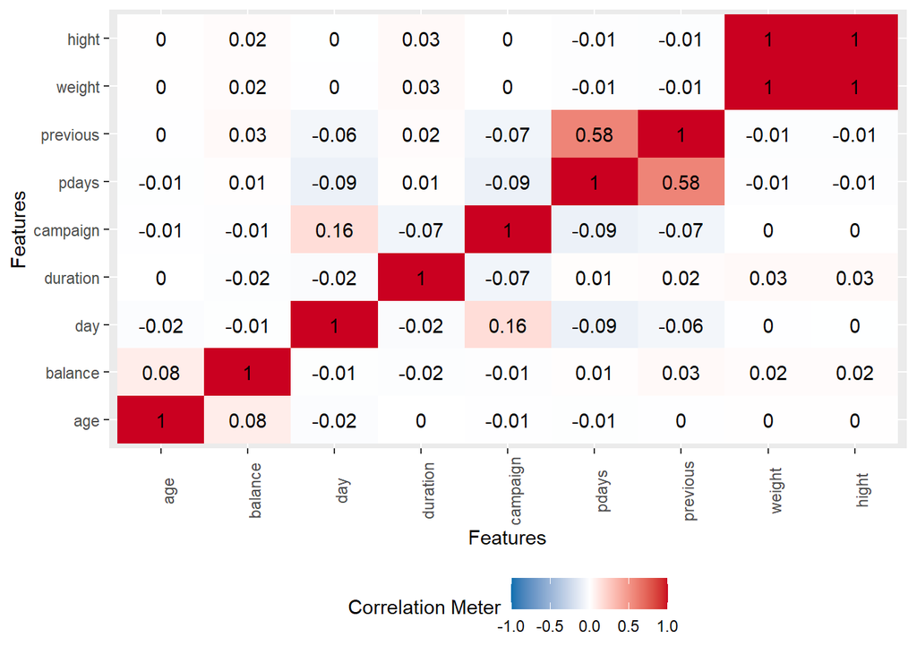

```r
plot_correlation(bank, type = "c")   # correlation matrix (default)
```

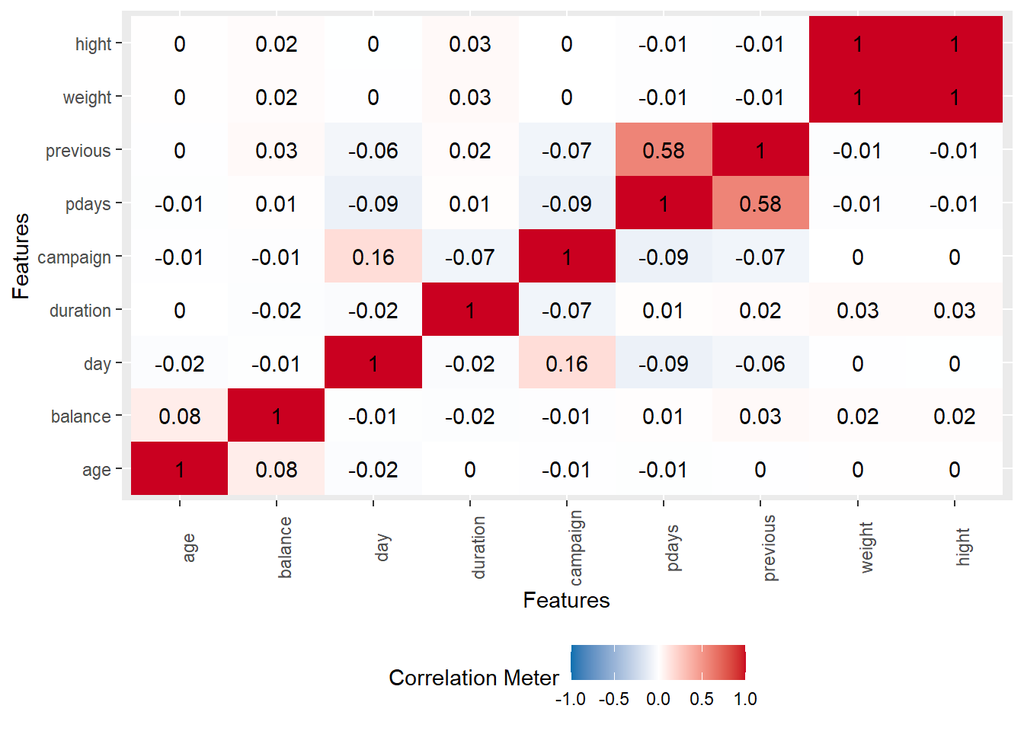

```r
plot_correlation(bank, type = "continuous")
```

## 2.corrplot

Package `corrplot` adalah package R yang digunakan sebagai alat eksplorasi visual untuk menampilkan matriks korelasi antar variabel. Package ini mendukung pengurutan variabel secara otomatis, sehingga membantu pengguna menemukan pola atau hubungan tersembunyi antar variabel yang mungkin sulit terlihat dari tabel angka biasa.

Package ini mudah digunakan dan menyediakan banyak pilihan visualisasi, seperti:

- berbagai metode plot (lingkaran, kotak, angka, dll),
- pengaturan tata letak grafik,
- warna,
- legend, dan
- label teks.

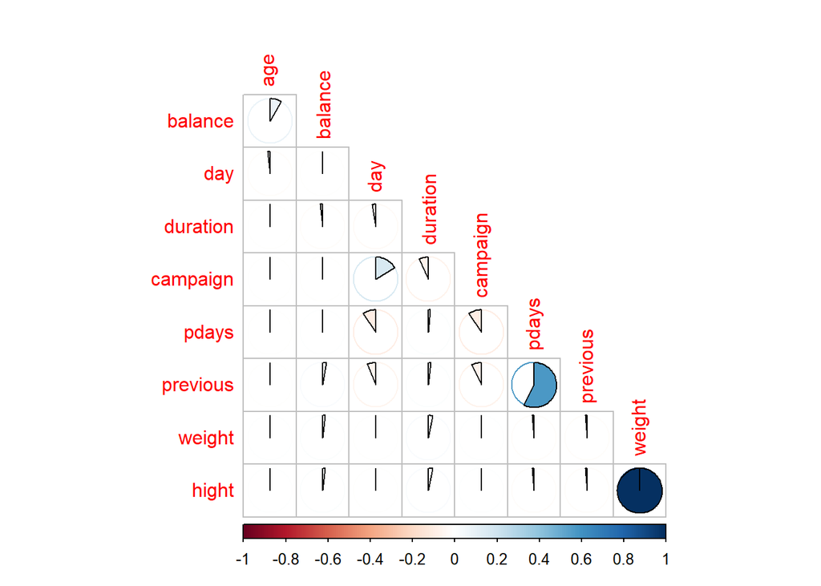

```r
#install.packages("corrplot")
library("corrplot")
library("tidyverse") #untuk menggunakan symbol %>%
# Membuat visualisasi matriks korelasi menggunakan corrplot
corrplot(

  # Menghitung matriks korelasi dari variabel numerik saja
  bank %>%
    select(where(is.numeric)) %>%  # Memilih hanya kolom bertipe numerik
    cor(),                           # Menghitung korelasi (default: Pearson)

  # Menentukan metode visualisasi korelasi
  method = "pie",    # Korelasi ditampilkan dalam bentuk diagram pie

  # Menentukan bagian matriks korelasi yang ditampilkan
  type = "lower",    # Hanya menampilkan bagian segitiga bawah matriks

  # Mengatur apakah diagonal utama ditampilkan
  diag = FALSE       # Tidak menampilkan korelasi variabel dengan dirinya sendiri
)
```

## 3. ggpubr

Package ggplot2 dikenal sebagai package yang sangat baik dan fleksibel untuk membuat visualisasi data yang elegan di R. Namun, grafik yang dihasilkan secara default masih memerlukan penyesuaian sebelum siap digunakan untuk publikasi ilmiah. Selain itu, proses kustomisasi grafik pada ggplot2 memiliki sintaks yang relatif kompleks, sehingga cukup menyulitkan bagi pengguna yang tidak memiliki kemampuan pemrograman R tingkat lanjut.

Package ggpubr hadir untuk mengatasi keterbatasan tersebut dengan menyediakan fungsi-fungsi yang mudah digunakan untuk membuat dan menyesuaikan grafik berbasis ggplot2 agar siap publikasi, tanpa memerlukan penulisan kode yang rumit.

```r
#install.packages("ggpubr")
library("ggpubr")
```

### Histogram

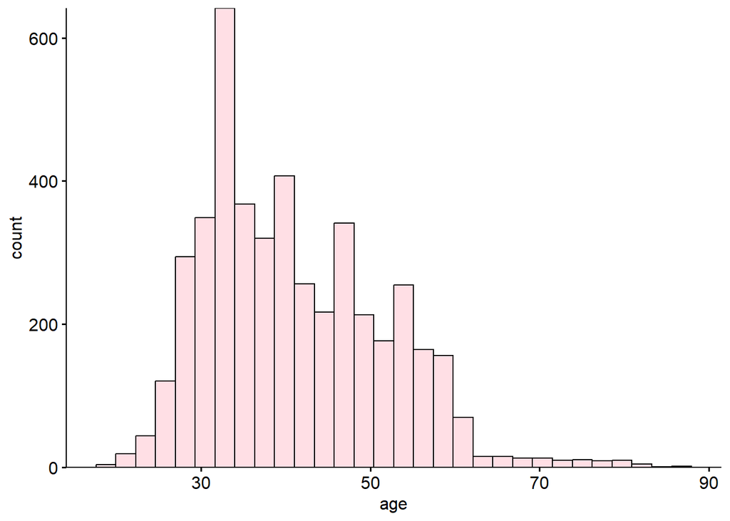

```r
# Membuat histogram distribusi variabel usia (age)
gghistogram(
  bank,          # Data frame yang digunakan
  x = "age",     # Variabel numerik yang akan ditampilkan pada sumbu X
  fill = "pink"  # Warna isi batang histogram
) +

  # Mengatur skala sumbu Y
  scale_y_continuous(
    expand = c(0, 0)  # Menghilangkan jarak kosong (padding) di awal dan akhir sumbu Y, batang histogram langsung nempel ke sumbu
  )
```

### Density Plot

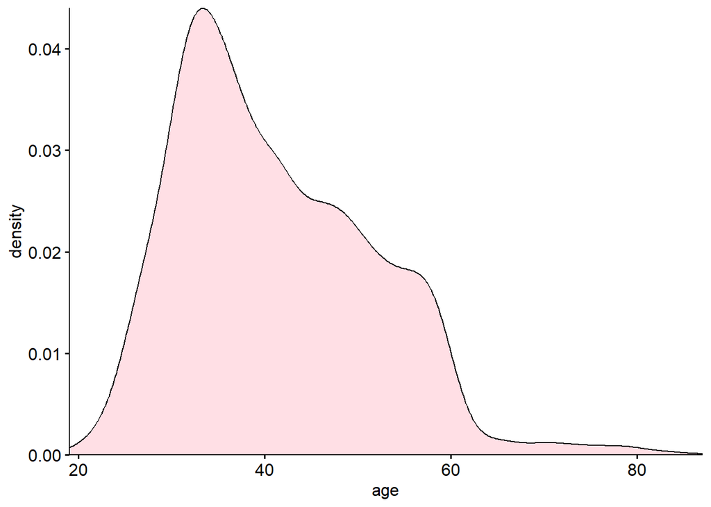

```r
ggdensity(bank,x ="age",fill ="pink")+
 scale_y_continuous(expand = c(0,0))+
 scale_x_continuous(expand = c(0,0))
```

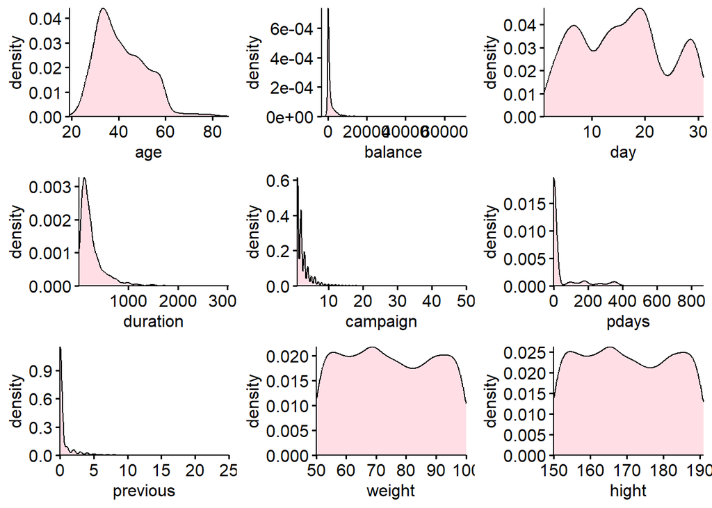

```r
# Mengambil nama kolom numerik dari data frame 'bank'
names_cont <- colnames(
  bank %>%
    select(where(is.numeric))  # Memilih kolom bertipe numerik
)

# Membuat list plot density untuk setiap variabel numerik
p1 <- map(
  names_cont,                # Iterasi setiap nama variabel numerik
  ~ ggdensity(
      bank,                  # Data yang digunakan
      x = .x,                # Variabel yang diplot
      fill = "pink"           # Warna area density
    ) +

    # Menghilangkan ruang kosong (padding) pada sumbu Y
    scale_y_continuous(expand = c(0, 0)) +

    # Menghilangkan ruang kosong (padding) pada sumbu X
    scale_x_continuous(expand = c(0, 0))
)

# Menggabungkan seluruh plot density dalam satu tampilan
ggarrange(plotlist = p1)
```

### ScatterPlot

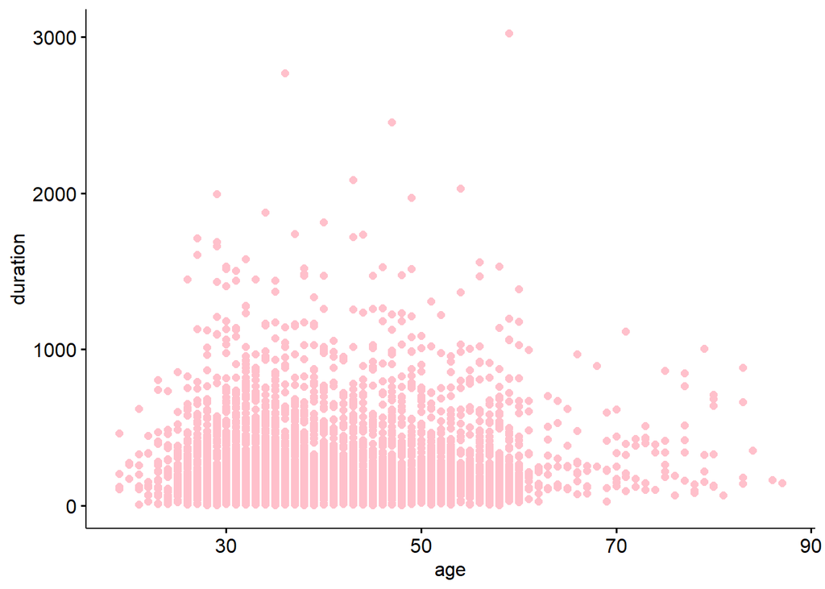

```r
ggscatter(bank,x = "age",y="duration",color = "pink")
```

```r
ggscatter(
  bank,
  x = "age",
  y = "duration",
  add = "reg.line",     # Tambah garis regresi
  conf.int = TRUE,      # Tambah interval kepercayaan
  point.params = list(color = "pink"),
  add.params = list(
    color = "blue",     # Warna garis regresi
    fill = "lightgray"  # Warna area confidence interval
  )
)
```

[figure not shown]

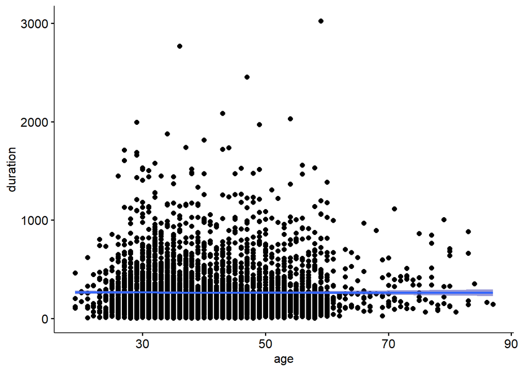

```r
ggscatter(
  bank,
  x = "age",
  y = "duration",
  add = "reg.line",
  add.params = list(color = "blue"),
  conf.int = TRUE
) +
  stat_smooth(method = "lm", se = TRUE)
```

## 4. ggplot2

```r
#install.packages("ggplot2")
library(ggplot2)
```

Satu Peubah:

Data Kontinu:

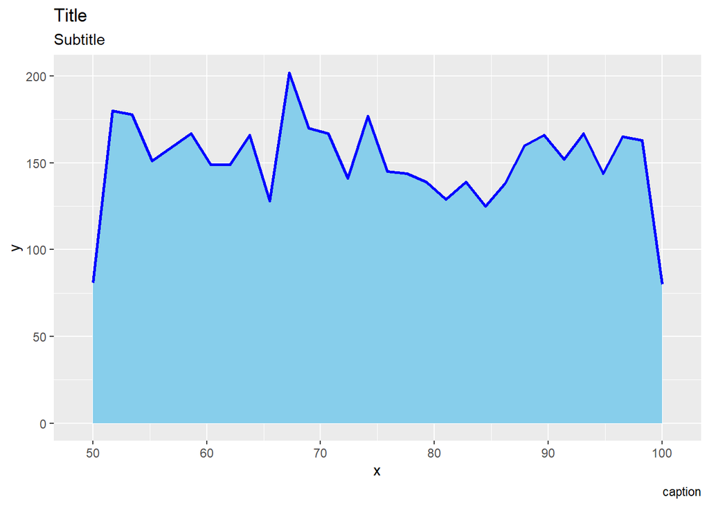

```r
# Membuat objek ggplot dengan data bank dan memetakan variabel weight ke sumbu X
a <- ggplot(bank, aes(x = weight))

# Menambahkan grafik area berbasis histogram (binning)
a +
  geom_area(
    stat = "bin",        # Mengelompokkan data ke dalam bin (interval) seperti histogram
    color = "blue",      # Warna garis tepi area
    fill = "skyblue",    # Warna isi area
    size = 1             # Ketebalan garis tepi
  ) +

  # Menambahkan keterangan pada grafik
  labs(
    x = "x",             # Label sumbu X
    y = "y",             # Label sumbu Y
    title = "Title",     # Judul utama grafik
    subtitle = "Subtitle", # Subjudul grafik
    caption = "caption" # Keterangan tambahan (biasanya sumber data)
  )
```

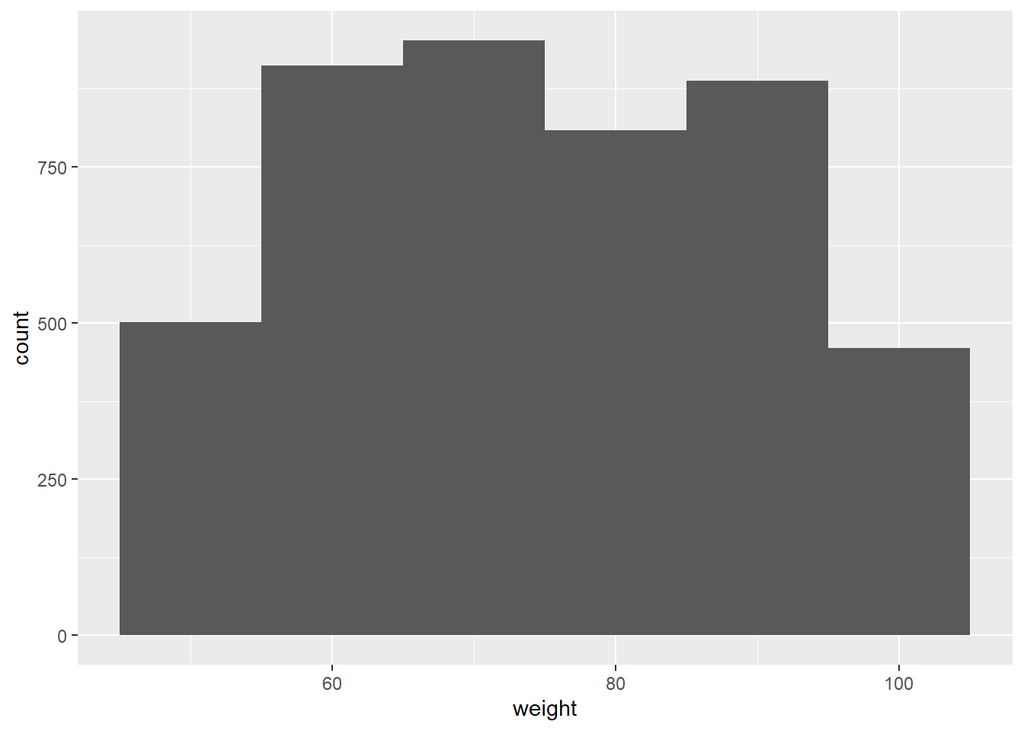

```r
a + geom_histogram(binwidth = 10) # Menentukan lebar setiap batang histogram (interval kelas = 10 satuan)
```

Data Diskret:

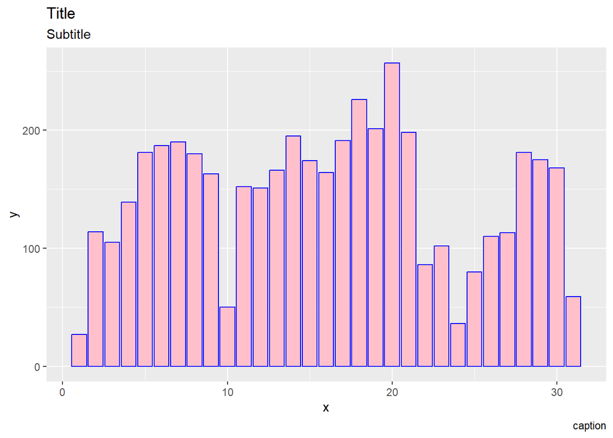

```r
b <- ggplot(bank, aes(day))
b + geom_bar(color="blue", fill = "pink") +
    labs(
      x = "x",
      y = "y",
      title = "Title",
      subtitle = "Subtitle",
      caption = "caption"
    )
```

Dua Peubah

X dan Y kontinu:

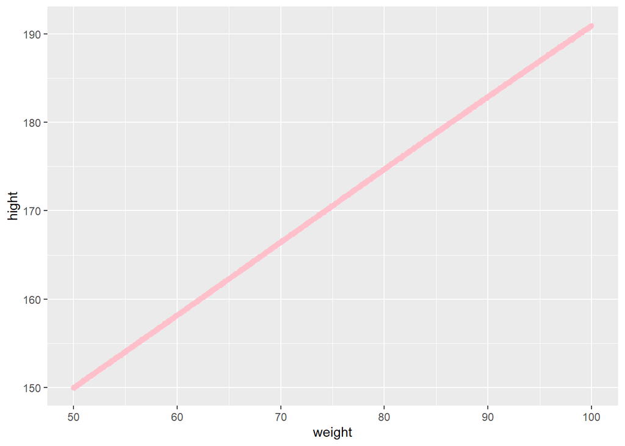

```r
# Membuat objek ggplot dengan data bank dan memetakan variabel
# weight ke sumbu X dan hight ke sumbu Y
f <- ggplot(bank, aes(weight, hight))

# Menambahkan jitter plot untuk mengurangi tumpang tindih titik data
f +
  geom_jitter(
    color = "pink",   # Warna titik
    size = 2,         # Ukuran titik
    shape = "o"       # Bentuk titik (lingkaran)
  )
```

X Diskret dan Y Kontinu:

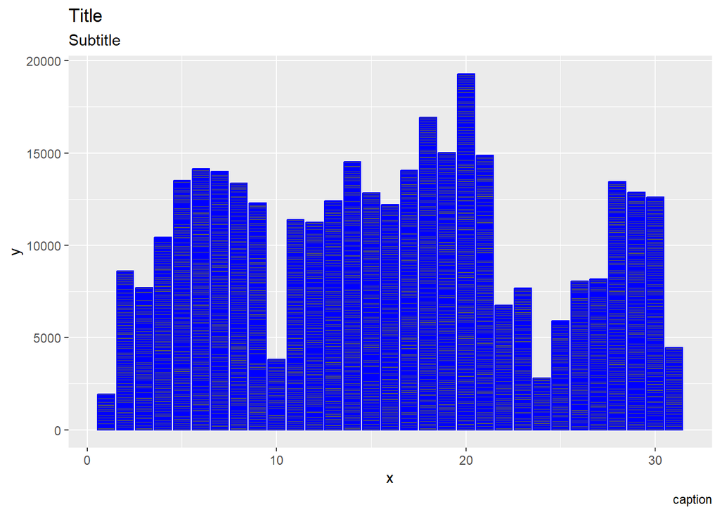

```r
# Membuat objek ggplot dengan data bank dan memetakan
# variabel day ke sumbu X dan weight ke sumbu Y
g <- ggplot(bank, aes(day, weight))

# Menambahkan bar chart dengan tinggi batang sesuai nilai weight
g +
  geom_bar(
    stat = "identity",   # Tinggi batang merepresentasikan nilai asli variabel weight
    color = "blue"       # Warna garis tepi batang
  ) +

  # Menambahkan keterangan pada grafik
  labs(
    x = "x",             # Label sumbu X
    y = "y",             # Label sumbu Y
    title = "Title",     # Judul utama grafik
    subtitle = "Subtitle", # Subjudul grafik
    caption = "caption" # Keterangan tambahan (misalnya sumber data)
  )
```

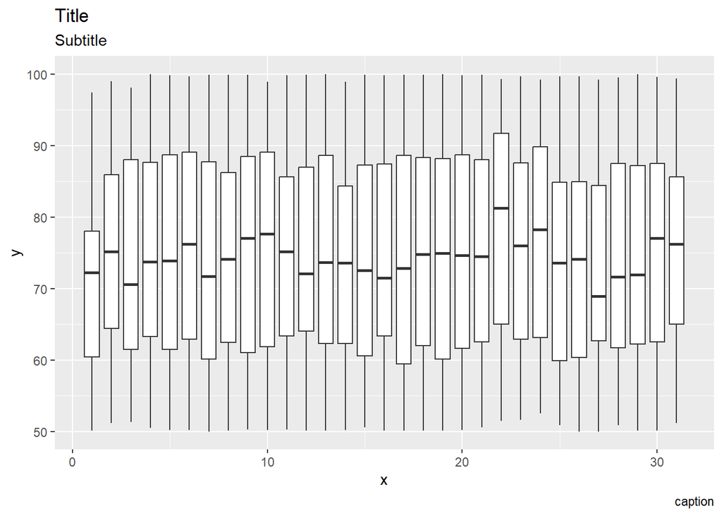

```r
# Membuat objek ggplot dengan data bank dan memetakan
# variabel day ke sumbu X dan weight ke sumbu Y
g <- ggplot(bank, aes(day, weight))

# Menambahkan boxplot untuk setiap kategori day
g +
  geom_boxplot(
    aes(group = day)   # Mengelompokkan data berdasarkan variabel day
  ) +

  # Menambahkan keterangan pada grafik
  labs(
    x = "x",             # Label sumbu X
    y = "y",             # Label sumbu Y
    title = "Title",     # Judul utama grafik
    subtitle = "Subtitle", # Subjudul grafik
    caption = "caption" # Keterangan tambahan (misalnya sumber data)
  )
```

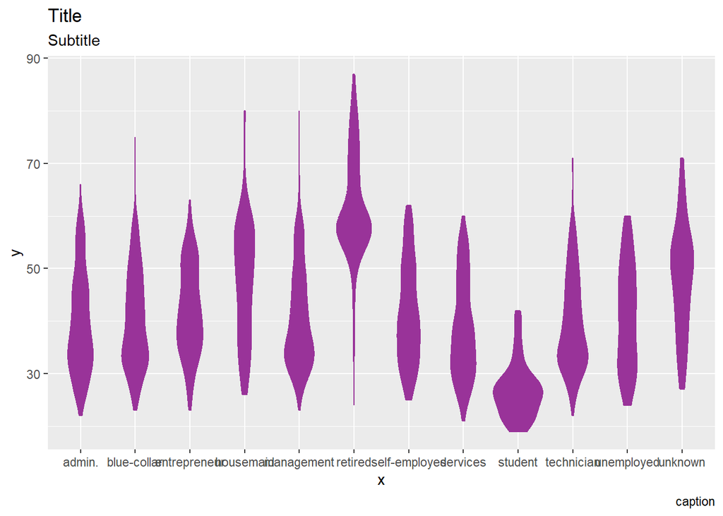

```r
# Membuat objek ggplot dengan data bank dan memetakan
# variabel job ke sumbu X dan age ke sumbu Y
g1 <- ggplot(bank, aes(job, age))

# Menambahkan violin plot untuk menampilkan distribusi usia (age)
# pada setiap kategori pekerjaan (job)
g1 +
  geom_violin(
    scale = "area",        # Menyamakan luas setiap violin agar dapat dibandingkan
    color = "#993399",     # Warna garis tepi violin
    fill = "#993399"       # Warna isi violin
  ) +

  # Menambahkan keterangan pada grafik
  labs(
    x = "x",               # Label sumbu X
    y = "y",               # Label sumbu Y
    title = "Title",       # Judul utama grafik
    subtitle = "Subtitle", # Subjudul grafik
    caption = "caption"   # Keterangan tambahan (misalnya sumber data)
  )
```

X Diskret dan Y Diskret

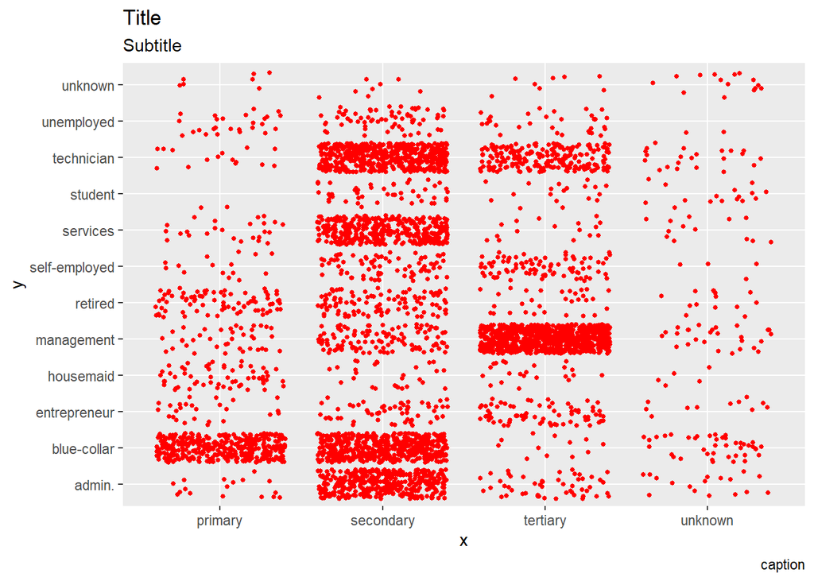

```r
# Membuat objek ggplot dengan data bank dan memetakan
# variabel education ke sumbu X dan job ke sumbu Y
h <- ggplot(bank, aes(education, job))

# Menambahkan jitter plot untuk menampilkan pasangan data
# education dan job agar titik tidak saling menumpuk
h +
  geom_jitter(
    colour = "red",  # Warna titik
    size = 1         # Ukuran titik
  ) +

  # Menambahkan keterangan pada grafik
  labs(
    x = "x",               # Label sumbu X
    y = "y",               # Label sumbu Y
    title = "Title",       # Judul utama grafik
    subtitle = "Subtitle", # Subjudul grafik
    caption = "caption"   # Keterangan tambahan (misalnya sumber data)
  )
```

# Fungsi Plot()

Fungsi plot() adalah fungsi bawaan R untuk membuat visualisasi dasar

Format dasar: plot(x, y, type = “…”, …)

KEUNTUNGAN plot():

- Lebih cepat untuk eksplorasi data sederhana
- Tidak perlu install package tambahan
- Sintaks lebih ringkas untuk plot sederhana

KEKURANGAN plot():

- Kurang fleksibel untuk customisasi kompleks
- Estetika kurang modern dibanding ggplot2
- Lebih sulit untuk membuat plot multi-layer

```r
set.seed(123)  # set.seed() untuk reproducibility (hasil random yang sama)
sample_data <- bank[sample(1:nrow(bank), 100), ]
```

- sample() = ambil sampel random 100 baris dari data
- nrow() = menghitung jumlah baris

Urutkan berdasarkan age untuk visualisasi yang lebih jelas

- order() = menghasilkan indeks urutan

```r
sample_data <- sample_data[order(sample_data$age), ]
```

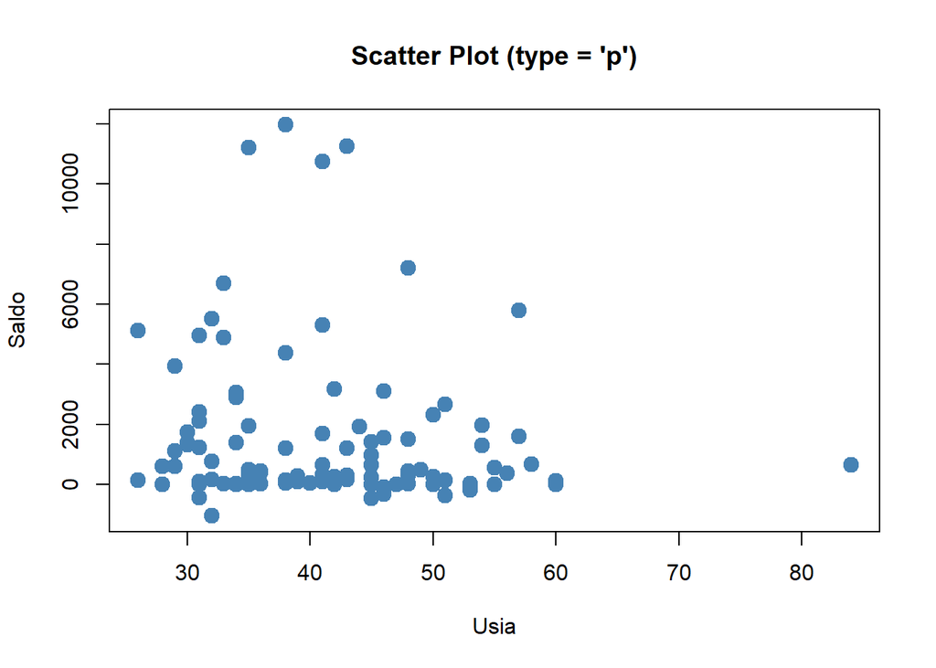

```r
# TYPE = "p" : Plot Titik (Scatter Plot)
# Ini adalah default type, membuat scatter plot
plot(sample_data$age, sample_data$balance,
     type = "p",  # "p" = points (titik)
     main = "Scatter Plot (type = 'p')",  # main = judul plot
     xlab = "Usia",                       # xlab = label sumbu x
     ylab = "Saldo",                      # ylab = label sumbu y
     col = "steelblue",                   # col = color (warna titik)
     pch = 19,                            # pch = plotting character (bentuk titik)
     cex = 1.5)                           # cex = character expansion (ukuran titik)
```

- pch = 19 adalah lingkaran solid (default)
- Angka pch lainnya: 0-25 (lihat penjelasan di bawah)

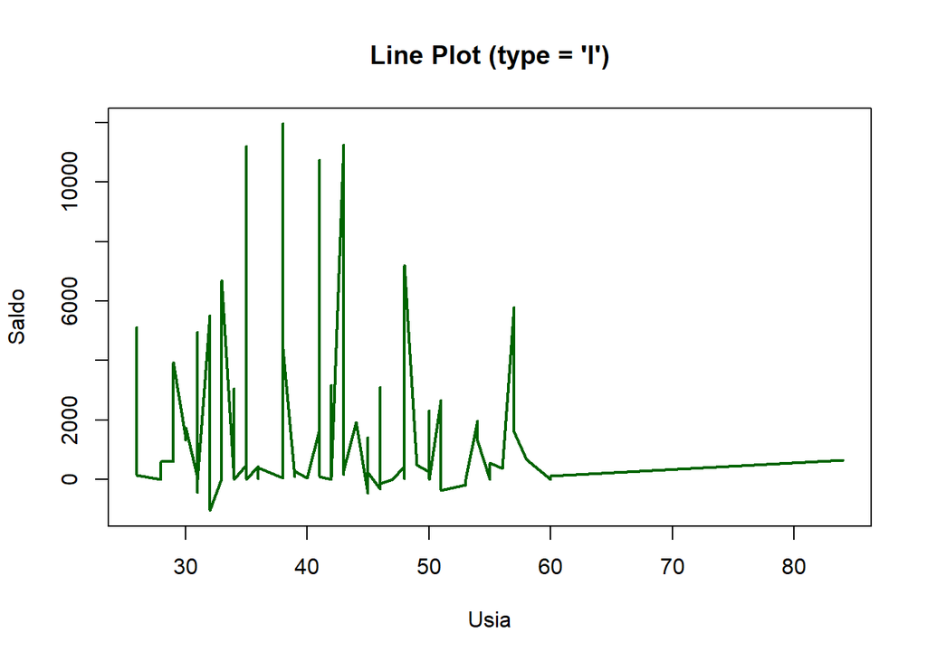

```r
# TYPE = "l" : Plot Garis (Line Plot)
# Menghubungkan titik-titik dengan garis tanpa menampilkan titik
plot(sample_data$age, sample_data$balance,
     type = "l",  # "l" = lines (garis)
     main = "Line Plot (type = 'l')",
     xlab = "Usia",
     ylab = "Saldo",
     col = "darkgreen",
     lwd = 2,     # lwd = line width (ketebalan garis)
     lty = 1)     # lty = line type (jenis garis)
```

```r
# lty options: 1=solid, 2=dashed, 3=dotted, 4=dotdash, 5=longdash, 6=twodash
# Cocok untuk data time series atau data yang berurutan
```

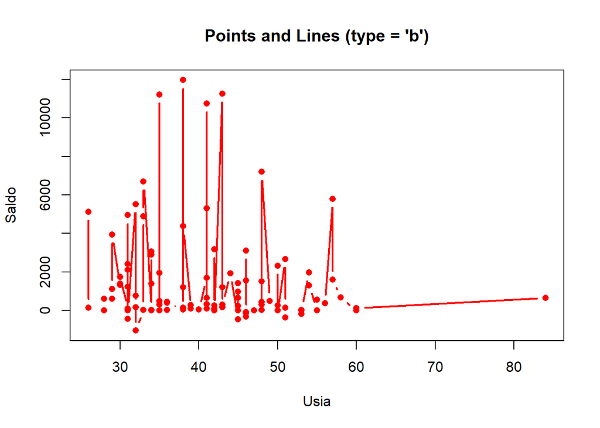

```r
# TYPE = "b" : Plot Titik dan Garis
# Menampilkan titik DAN garis, dengan jarak antara titik dan garis
plot(sample_data$age, sample_data$balance,
     type = "b",  # "b" = both (titik dan garis)
     main = "Points and Lines (type = 'b')",
     xlab = "Usia",
     ylab = "Saldo",
     col = "red",
     pch = 16,    # pch 16 = lingkaran solid kecil
     lwd = 2)
```

```r
# Ada jarak kecil antara titik dan garis
# Berguna untuk melihat data point sekaligus trendnya
```

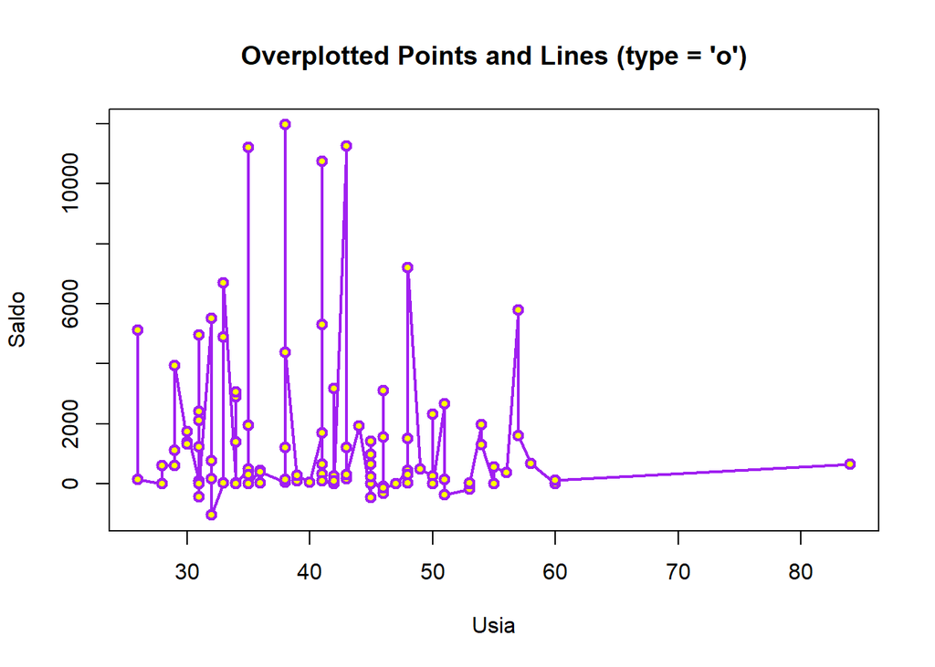

```r
# TYPE = "o" : Plot Titik Overlapped dengan Garis
# Garis MENEMBUS titik (overplotted)
plot(sample_data$age, sample_data$balance,
     type = "o",  # "o" = overplotted (titik ditimpa garis)
     main = "Overplotted Points and Lines (type = 'o')",
     xlab = "Usia",
     ylab = "Saldo",
     col = "purple",
     pch = 21,    # pch 21 = lingkaran dengan border
     bg = "yellow",  # bg = background color (warna isi titik untuk pch 21-25)
     lwd = 2)
```

```r
# Perbedaan dengan type="b": garis menembus titik, tidak ada jarak
# pch 21-25 memiliki fill dan border terpisah
```

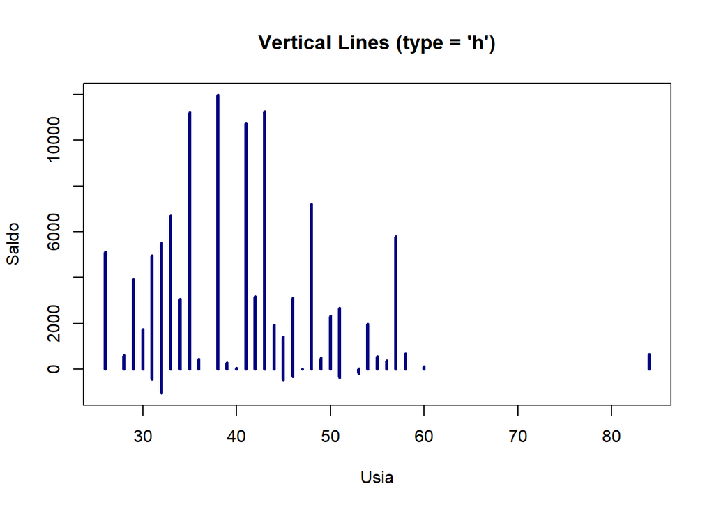

```r
# TYPE = "h" : Plot Garis Vertikal (Histogram-like)
# Membuat garis vertikal dari setiap titik ke y=0
plot(sample_data$age, sample_data$balance,
     type = "h",  # "h" = histogram-like vertical lines
     main = "Vertical Lines (type = 'h')",
     xlab = "Usia",
     ylab = "Saldo",
     col = "navy",
     lwd = 3)
```

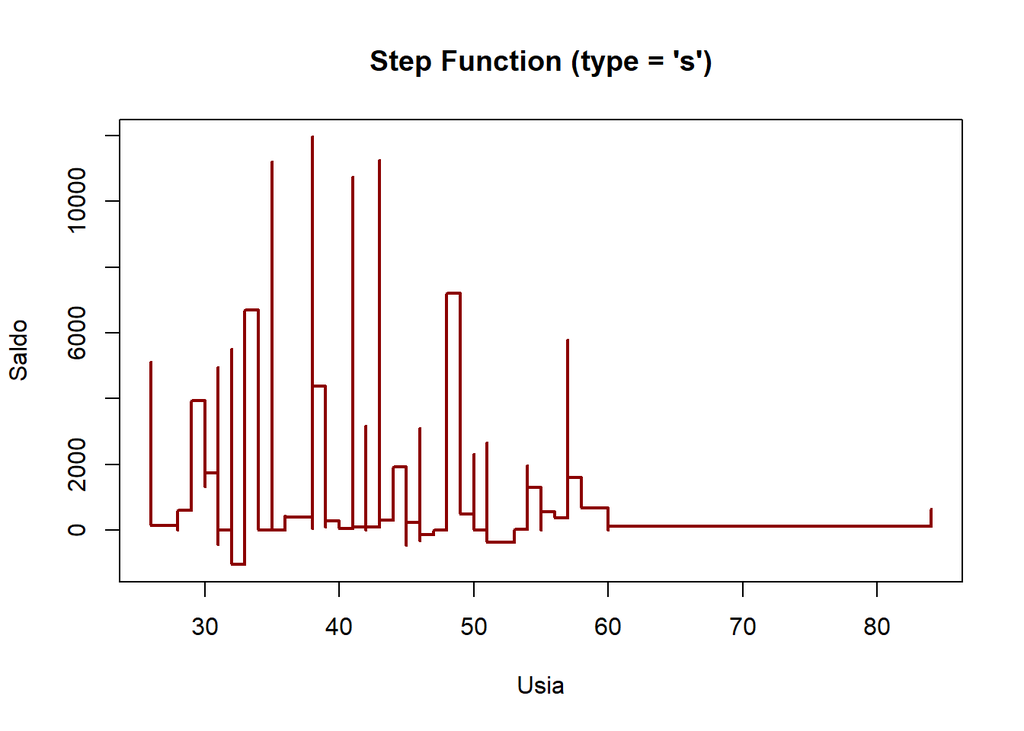

```r
# TYPE = "s" : Plot Tangga (Step Function)
# Membuat fungsi tangga (step function)
plot(sample_data$age, sample_data$balance,
     type = "s",  # "s" = steps (tangga)
     main = "Step Function (type = 's')",
     xlab = "Usia",
     ylab = "Saldo",
     col = "darkred",
     lwd = 2)
```

```r
# Berguna untuk visualisasi data diskrit atau data yang berubah bertahap
# Garis horizontal dulu, baru vertikal
# Ada juga type="S" (huruf besar) yang vertikal dulu, baru horizontal
```

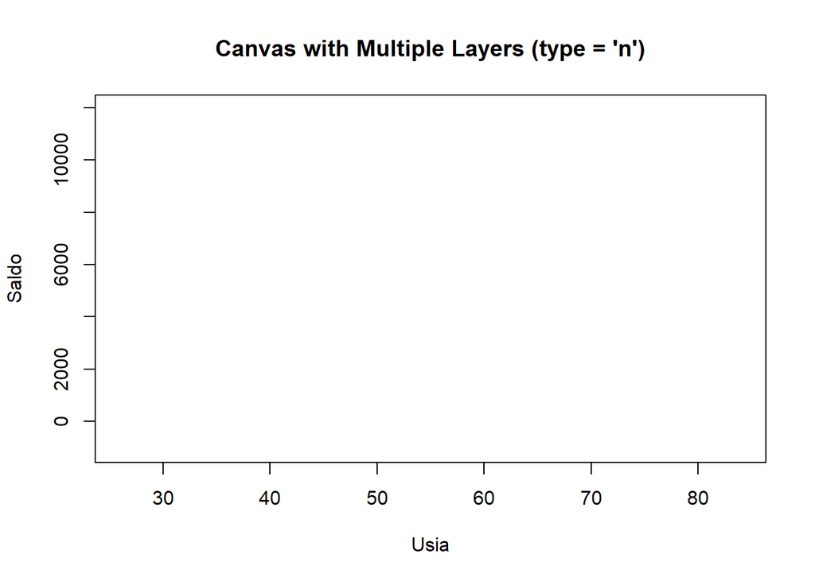

```r
# TYPE = "n" : No Plotting (Hanya Sumbu)
# Tidak membuat plot sama sekali, hanya setup sumbu
# Berguna sebagai "canvas" untuk plot kustom bertahap
plot(sample_data$age, sample_data$balance,
     type = "n",  # "n" = no plotting
     main = "Canvas with Multiple Layers (type = 'n')",
     xlab = "Usia",
     ylab = "Saldo")
```

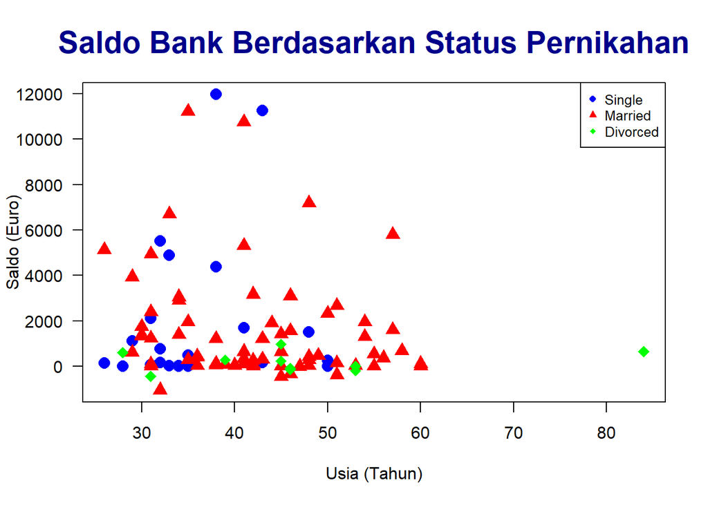

```r
plot(sample_data$age, sample_data$balance,
     type = "n",

     # Setup judul dan label
     main = "Saldo Bank Berdasarkan Status Pernikahan",
     xlab = "Usia (Tahun)",
     ylab = "Saldo (Euro)",

     # Setup range sumbu
     xlim = range(sample_data$age),
     ylim = range(sample_data$balance),

     # Kustomisasi
     cex.main = 1.8,
     col.main = "darkblue",
     las = 1
)

# Tambahkan layer-layer secara manual:
# Layer 1: Tambah titik untuk kategori tertentu
points(sample_data$age[sample_data$marital == "single"],
       sample_data$balance[sample_data$marital == "single"],
       col = "blue", pch = 16, cex = 1.5)

# Layer 2: Tambah titik untuk kategori lain
points(sample_data$age[sample_data$marital == "married"],
       sample_data$balance[sample_data$marital == "married"],
       col = "red", pch = 17, cex = 1.5)

# Layer 3: Tambah titik untuk kategori lain lagi
points(sample_data$age[sample_data$marital == "divorced"],
       sample_data$balance[sample_data$marital == "divorced"],
       col = "green", pch = 18, cex = 1.5)

# Tambah legend
legend("topright",  # posisi legend: "topleft", "topright", "bottomleft", "bottomright"
       legend = c("Single", "Married", "Divorced"),
       col = c("blue", "red", "green"),
       pch = c(16, 17, 18),
       cex = 0.8)  # cex di legend mengatur ukuran teks legend
```

`PENJELASAN PARAMETER PLOT() YANG SERING DIGUNAKAN`

PARAMETER WARNA (col, bg):

- col = warna utama (titik, garis, border)
- bg = background/fill color (hanya untuk pch 21-25)

Cara menentukan warna:

1. Nama: “red”, “blue”, “steelblue”, “darkgreen”
2. Hex code: “#FF5733”
3. RGB: rgb(255, 87, 51, maxColorValue=255)
4. Angka: 1=black, 2=red, 3=green, 4=blue, dst

PARAMETER PCH (plotting character):

pch menentukan bentuk titik:

0 = kotak kosong 15 = kotak solid

1 = lingkaran kosong 16 = lingkaran solid

2 = segitiga atas kosong 17 = segitiga atas solid

3 = plus (+) 18 = diamond solid

4 = cross (x) 19 = lingkaran solid besar

5 = diamond kosong 20 = titik kecil solid

6 = segitiga bawah kosong

7-14 = variasi lainnya

21 = lingkaran dengan fill dan border

22 = kotak dengan fill dan border

23 = diamond dengan fill dan border

24 = segitiga atas dengan fill dan border

25 = segitiga bawah dengan fill dan border

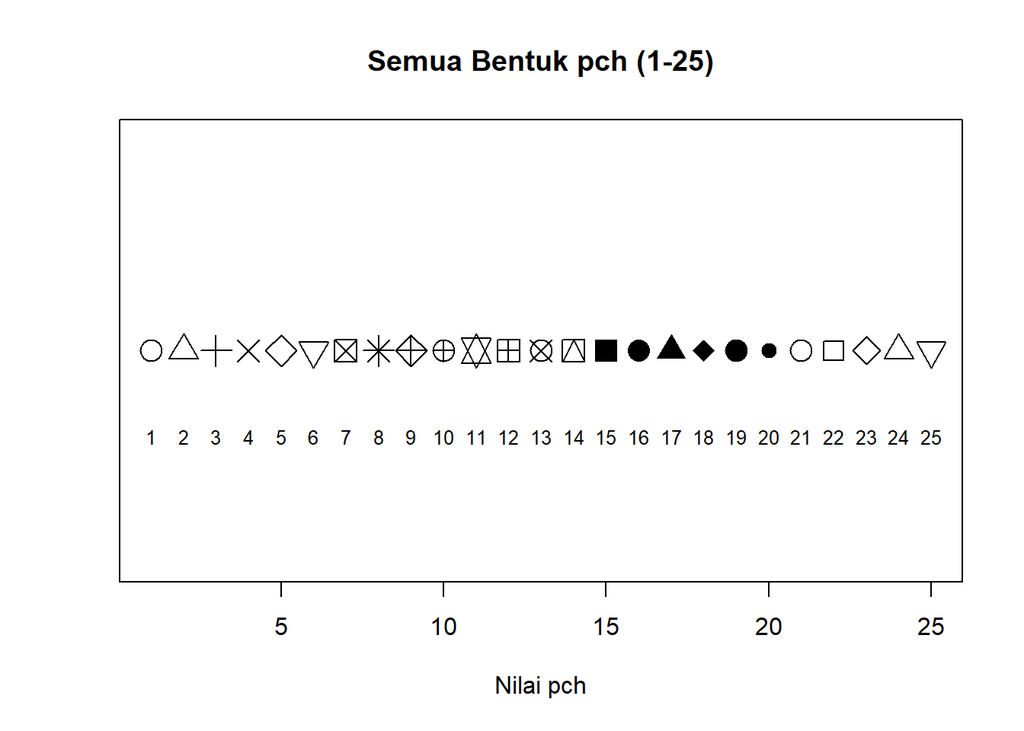

```r
# Semua pch:
plot(1:25, rep(1, 25), pch = 1:25, cex = 2,
     main = "Semua Bentuk pch (1-25)",
     xlab = "Nilai pch", ylab = "",
     ylim = c(0.5, 1.5), yaxt = "n")
# ylim = batas sumbu y
# yaxt = "n" menghilangkan axis y
text(1:25, rep(0.8, 25), labels = 1:25, cex = 0.8)
```

```r
# text() menambahkan teks pada koordinat tertentu
```

`PARAMETER CEX (character expansion):`

Mengatur ukuran elemen:

- cex = ukuran umum
- cex.main = ukuran judul
- cex.lab = ukuran label axis
- cex.axis = ukuran angka di axis

Default = 1, lebih besar = lebih besar, lebih kecil = lebih kecil

`PARAMETER LWD (line width):`

Mengatur ketebalan garis

Default = 1

lwd = 2 (dua kali lebih tebal), lwd = 0.5 (setengah)

`PARAMETER LTY (line type):`

1 = solid (garis utuh) ———————

2 = dashed (putus-putus) — — — —

3 = dotted (titik-titik) · · · · · ·

4 = dotdash (titik-garis) · — · —

5 = longdash (garis panjang) —— —— ——

6 = twodash (dua garis) — — — —

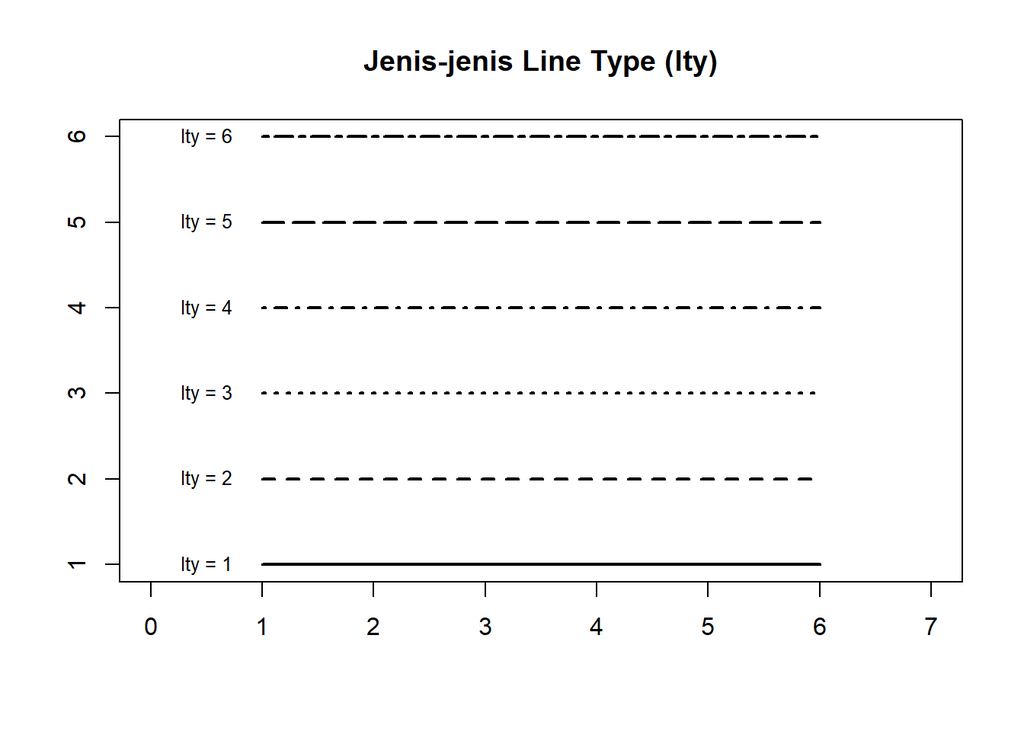

```r
#Line types:
plot(1:6, 1:6, type = "n",
     main = "Jenis-jenis Line Type (lty)",
     xlab = "", ylab = "", xlim = c(0, 7))
for(i in 1:6) {
  lines(c(1, 6), c(i, i), lty = i, lwd = 2)
  text(0.5, i, paste("lty =", i), cex = 0.8)
}
```

# Kustomisasi

## Scatter Plot

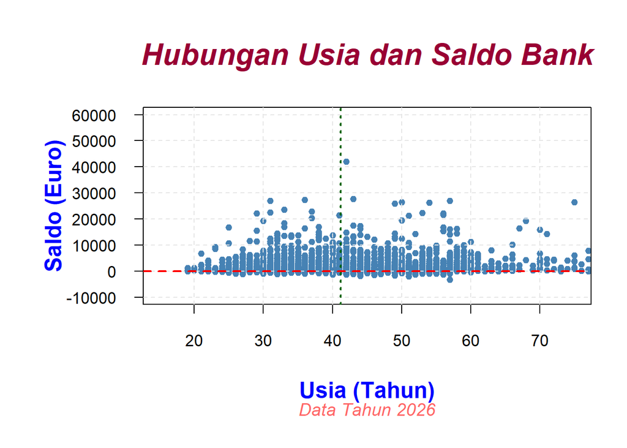

```r
# Mengatur jarak teks sumbu
# mgp = c(jarak_judul, jarak_angka, jarak_garis)
par(
  mar = c(8, 8, 6, 2),      # Margin (bawah, kiri, atas, kanan)
                            # mar = c(bottom, left, top, right)
  mgp = c(4.4, 1.5, 0)      # Menggeser posisi teks sumbu
                            # mgp = c(axis.title, axis.label, axis.line)
)

plot(
  bank$age, bank$balance,
  type = "p",               # "p" = point (scatter plot)

  main = "Hubungan Usia dan Saldo Bank",   # Judul utama
  sub  = "Data Tahun 2026",                # Sub-judul
  xlab = "Usia (Tahun)",                   # Label sumbu X
  ylab = "Saldo (Euro)",                   # Label sumbu Y

  col = "steelblue",       # Warna titik
  col.main = "#990033",    # Warna judul
  col.lab  = "blue",       # Warna label sumbu
  col.sub  = "#ff6666",    # Warna sub-judul

  cex = 0.9,               # Ukuran titik
  cex.main = 2,            # Ukuran teks judul utama
  cex.lab  = 1.5,          # Ukuran teks label sumbu
  cex.sub  = 1.2,          # Ukuran teks sub-judul
  cex.axis = 1.1,          # Ukuran teks angka sumbu

  font.main = 4,           # Style font judul (4 = italic)
  font.lab  = 2,           # Style font label (2 = bold)
  font.sub  = 3,           # Style font sub (3 = italic)

  pch = 19,                # Bentuk titik (19 = solid circle)

  xlim = c(15, 75),        # Batas sumbu X
  ylim = c(-10000, 60000), # Batas sumbu Y

  las = 1,                 # Agar angka sumbu horizontal (0=default)
  bg = "white"             # Background plot
)

grid(col = "gray90", lty = 2, lwd = 1)  # Menambahkan grid

abline(h = 0, col = "red", lwd = 2, lty = 2)           # Garis horizontal di y=0
abline(v = mean(bank$age), col = "darkgreen", lwd = 2, lty = 3) # Garis vertikal rata-rata usia
```

## Scatter Plot dengan Kategori dan Label

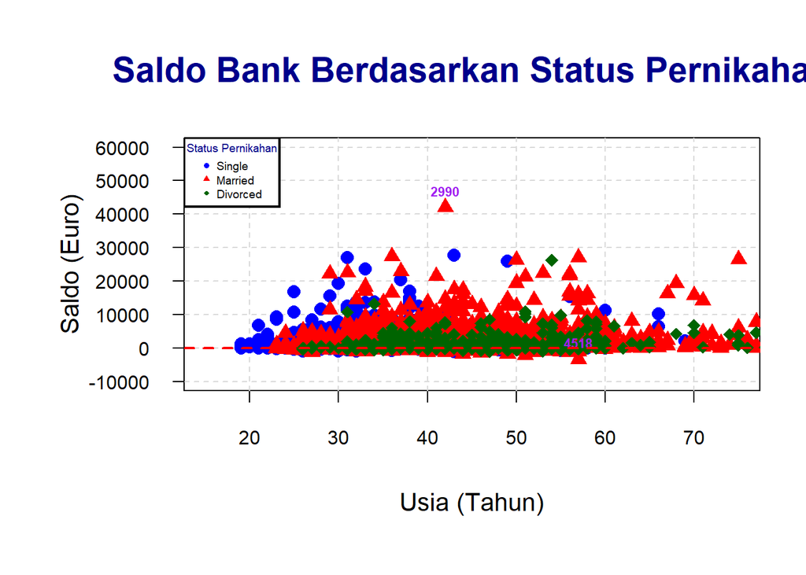

```r
# Mengatur jarak teks sumbu
# mgp = c(jarak_judul, jarak_angka, jarak_garis)
par(mar = c(8, 8, 6, 2),      # Margin kiri diperbesar
    mgp = c(4.4, 1.5, 0))      # Label sumbu Y digeser menjauh

# Filter data dengan balance ekstrem
extreme_data <- bank[bank$balance > 40000 | bank$balance < -3000, ]

plot(bank$age, bank$balance,
     type = "n",              # "n" = no plotting, hanya setup canvas

     main = "Saldo Bank Berdasarkan Status Pernikahan",
     xlab = "Usia (Tahun)",
     ylab = "Saldo (Euro)",

     cex.main = 1.8,
     col.main = "darkblue",
     font.main = 2,

     cex.lab = 1.3,

     las = 1,

     xlim = c(15, 75),
     ylim = c(-10000, 60000)
)

# Tambahkan grid dulu (di belakang)
grid(col = "gray85", lty = 2)

# Tambahkan titik untuk setiap kategori dengan warna berbeda
# Single
points(bank$age[bank$marital == "single"],
       bank$balance[bank$marital == "single"],
       col = "blue",         # Warna untuk single
       pch = 16,             # Lingkaran solid
       cex = 1.5)            # Ukuran titik

# Married
points(bank$age[bank$marital == "married"],
       bank$balance[bank$marital == "married"],
       col = "red",          # Warna untuk married
       pch = 17,             # Segitiga
       cex = 1.5)

# Divorced
points(bank$age[bank$marital == "divorced"],
       bank$balance[bank$marital == "divorced"],
       col = "darkgreen",    # Warna untuk divorced
       pch = 18,             # Diamond
       cex = 1.5)

# Tambahkan text label untuk data ekstrem
text(x = extreme_data$age,     # Koordinat X
     y = extreme_data$balance, # Koordinat Y
     labels = rownames(extreme_data), # Teks yang ditampilkan
     col = "purple",          # Warna teks
     cex = 0.7,               # Ukuran teks
     pos = 3,                 # Posisi: 1=bawah, 2=kiri, 3=atas, 4=kanan
     font = 2)                # Bold

# Tambahkan garis horizontal di y=0
abline(h = 0, col = "red", lwd = 2, lty = 2)

# Tambahkan legend
legend("topleft",
       legend = c("Single", "Married", "Divorced"),
       col = c("blue", "red", "darkgreen"),
       pch = c(16, 17, 18),
       cex = 0.6,
       bg = "white",
       box.lwd = 2,
       title = "Status Pernikahan",
       title.col = "darkblue")
```